# Prediction Project

Samuel

5 janvier 2018

# Machine Learning Final Project

## Introduction

### Background

Using devices such as Jawbone Up, Nike FuelBand, and Fitbit it is now possible to collect a large amount of data about personal activity relatively inexpensively. These type of devices are part of the quantified self movement - a group of enthusiasts who take measurements about themselves regularly to improve their health, to find patterns in their behavior, or because they are tech geeks. One thing that people regularly do is quantify how much of a particular activity they do, but they rarely quantify how well they do it. In this project, your goal will be to use data from accelerometers on the belt, forearm, arm, and dumbell of 6 participants. They were asked to perform barbell lifts correctly and incorrectly in 5 different ways. More information is available from the website here: http://groupware.les.inf.puc-rio.br/har (see the section on the Weight Lifting Exercise Dataset).

### Data

The training data for this project are available here: https://d396qusza40orc.cloudfront.net/predmachlearn/pml-training.csv The test data are available here: https://d396qusza40orc.cloudfront.net/predmachlearn/pml-testing.csv The data for this project come from this source: http://groupware.les.inf.puc-rio.br/har. If you use the document you create for this class for any purpose please cite them as they have been very generous in allowing their data to be used for this kind of assignment.

## Data preparation

### Importing the data

```r
setwd("D:/Cours/Coursera/ML")

#Dowlanding training and testing sets
url1 <- 'https://d396qusza40orc.cloudfront.net/predmachlearn/pml-training.csv'
trainingDL <- basename(url1);
if (!file.exists(trainingDL)) {
  download.file(url1, trainingDL, method='curl')
}

url2 <- 'https://d396qusza40orc.cloudfront.net/predmachlearn/pml-testing.csv'
testingDL <- basename(url2);
if (!file.exists(testingDL)) {
  download.file(url1, testingDL, method='curl')
}
```

```r
#Importing the data
training <- read.csv(trainingDL)
testing <- read.csv(testingDL)
```

### Cleaning the data

```r
#A few columns have only ~400 values out of 19622 filled for each window, and a few of them basically are all "div by 0"

emptyColsTrain2 <- training[which((summarise_all(training, funs(sum(grepl("DIV", .)))) > 100))]

trainingV1 <- training[, !(names(training) %in% names(emptyColsTrain2))]
testingV1 <- testing[, !(names(training) %in% names(emptyColsTrain2))]


#when window is "yes", more measures, so I keep them in a separate dataset to see if any impact
#and keep another data sets with reduced column numbers
trainingW = trainingV1 %>% filter(new_window == "yes")
trainingNW = trainingV1 %>% filter(new_window == "no")

testingW = testingV1 %>% filter(new_window == "yes")
testingNW = testingV1 %>% filter(new_window == "no")

#Getting the mostly empty columns out
emptyCols <- trainingNW[,which(summarise_all(trainingNW, funs(sum(grepl("^$", .)))) > 10)]
trainingNW <- trainingNW[, !(names(trainingNW) %in% names(emptyCols))]

NACols <- trainingNW[,which(summarise_all(trainingNW, funs(sum(is.na(.)))) > 100)]
trainingNW <- trainingNW[, !(names(trainingNW) %in% names(NACols))]
testingNW <- testingNW[, (names(testingNW) %in% names(trainingNW))]

#Transforming the time data into hour of the day and day of the week, then deleting the others timestamp and indexes column which hold no informations
trainingNW2 <- trainingNW %>% mutate(cvtd_timestamp = as.POSIXct((cvtd_timestamp), format = "%d/%m/%Y %H:%M"))
trainingNW2 <- trainingNW2 %>%
    separate(cvtd_timestamp, c("weekday","hour"), sep = " ")
trainingNW3 <- trainingNW2 %>%
    mutate(weekday = as.factor(weekdays(as.Date(weekday, "%Y-%m-%d"))), hour = as.factor(substr(trainingNW2$hour, 0, 2)))
trainingNW3 <- trainingNW3 %>% select(-c(1:4,7,8))
trainingNW3 <- trainingNW3 %>% mutate_at(c(3:54), funs(as.numeric(.)))
#Converting the day and hour column into dummies
dmyTrain <- dummyVars( ~ weekday + hour, data = trainingNW3)
dummyTrain <- data.frame(predict(dmyTrain, newdata = trainingNW3))
finalTrain <- cbind(dummyTrain, trainingNW3) %>% select(-c(weekday, hour))

#Same for test data
testingNW2 <- testingNW %>% mutate(cvtd_timestamp = as.POSIXct((cvtd_timestamp), format = "%d/%m/%Y %H:%M"))
testingNW2 <- testingNW2 %>%
    separate(cvtd_timestamp, c("weekday","hour"), sep = " ")
testingNW3 <- testingNW2 %>%
    mutate(weekday = as.factor(weekdays(as.Date(weekday, "%Y-%m-%d"))), hour = as.factor(substr(testingNW2$hour, 0, 2)))
testingNW3 <- testingNW3 %>% select(-c(1:4,7,8))
testingNW3 <- testingNW3 %>% mutate_at(c(3:54), funs(as.numeric(.)))

dmyTest <- dummyVars( ~ weekday + hour, data = testingNW3)
dummyTest <- data.frame(predict(dmyTest, newdata = testingNW3))
finalTest <- cbind(dummyTest, testingNW3) %>% select(-c(weekday, hour))
```

```r
#We split the training set into training and testing set to keep the test data as validation set for the out of sample error
set.seed(123)
inTrain <- createDataPartition(finalTrain$classe, p = 3/4, list = FALSE)
trainData <- finalTrain[inTrain, ]
testData <- finalTrain[-inTrain, ]
```

## Prediction

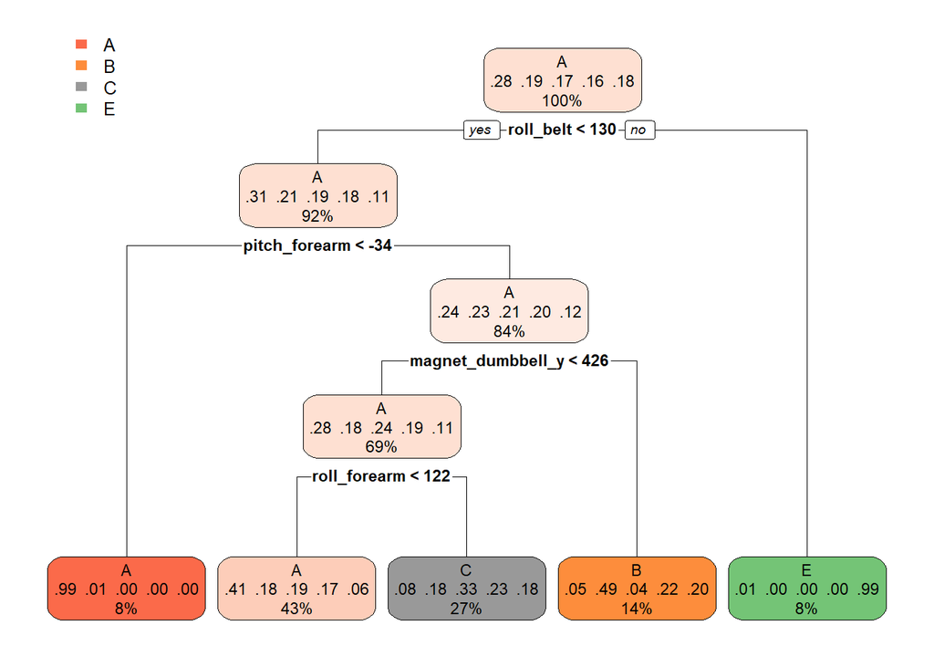

```r
#Let's first start with a simple tree model
set.seed(123)

modT <- train(classe ~., data = trainData, method = "rpart")

predicT <- predict(modT, newdata = testData)

rpart.plot(modT$finalModel)
```

```r
confusionMatrix(predicT, testData$classe)
```

```
## Confusion Matrix and Statistics
##
##           Reference
## Prediction    A    B    C    D    E
##          A 1234  368  379  334  129
##          B   27  325   37  146  107
##          C  100  236  422  306  226
##          D    0    0    0    0    0
##          E    6    0    0    0  420
##
## Overall Statistics
##
##                Accuracy : 0.5
##                  95% CI : (0.4858, 0.5142)
##     No Information Rate : 0.2847
##     P-Value [Acc > NIR] : < 2.2e-16
##
##                   Kappa : 0.3473
##  Mcnemar's Test P-Value : NA
##
## Statistics by Class:
##
##                      Class: A Class: B Class: C Class: D Class: E
## Sensitivity            0.9027  0.34984  0.50358   0.0000  0.47619
## Specificity            0.6477  0.91815  0.78103   1.0000  0.99847
## Pos Pred Value         0.5049  0.50623  0.32713      NaN  0.98592
## Neg Pred Value         0.9436  0.85481  0.88155   0.8363  0.89442
## Prevalence             0.2847  0.19346  0.17451   0.1637  0.18367
## Detection Rate         0.2570  0.06768  0.08788   0.0000  0.08746
## Detection Prevalence   0.5090  0.13369  0.26864   0.0000  0.08871
## Balanced Accuracy      0.7752  0.63399  0.64230   0.5000  0.73733
```

Only 50% accuracy, with way too many As predicted - very specific for the other classes.

```r
#Random forest, I am no using caret package because after 30 minutes, I had still no results
set.seed(123)


modRF <- randomForest(classe ~., data = trainData)

predicTree <- predict(modRF, newdata = testData)

confusionMatrix(predicTree, testData$classe)
```

```
## Confusion Matrix and Statistics
##
##           Reference
## Prediction    A    B    C    D    E
##          A 1367    0    0    0    0
##          B    0  929    1    0    0
##          C    0    0  835   13    0
##          D    0    0    2  773    1
##          E    0    0    0    0  881
##
## Overall Statistics
##
##                Accuracy : 0.9965
##                  95% CI : (0.9943, 0.9979)
##     No Information Rate : 0.2847
##     P-Value [Acc > NIR] : < 2.2e-16
##
##                   Kappa : 0.9955
##  Mcnemar's Test P-Value : NA
##
## Statistics by Class:
##
##                      Class: A Class: B Class: C Class: D Class: E
## Sensitivity            1.0000   1.0000   0.9964   0.9835   0.9989
## Specificity            1.0000   0.9997   0.9967   0.9993   1.0000
## Pos Pred Value         1.0000   0.9989   0.9847   0.9961   1.0000
## Neg Pred Value         1.0000   1.0000   0.9992   0.9968   0.9997
## Prevalence             0.2847   0.1935   0.1745   0.1637   0.1837
## Detection Rate         0.2847   0.1935   0.1739   0.1610   0.1835
## Detection Prevalence   0.2847   0.1937   0.1766   0.1616   0.1835
## Balanced Accuracy      1.0000   0.9999   0.9966   0.9914   0.9994
```

We obtain a (way too) amazing accuracy of 0.9965. There is a risk of overfitting, however the results are still impressive enough.

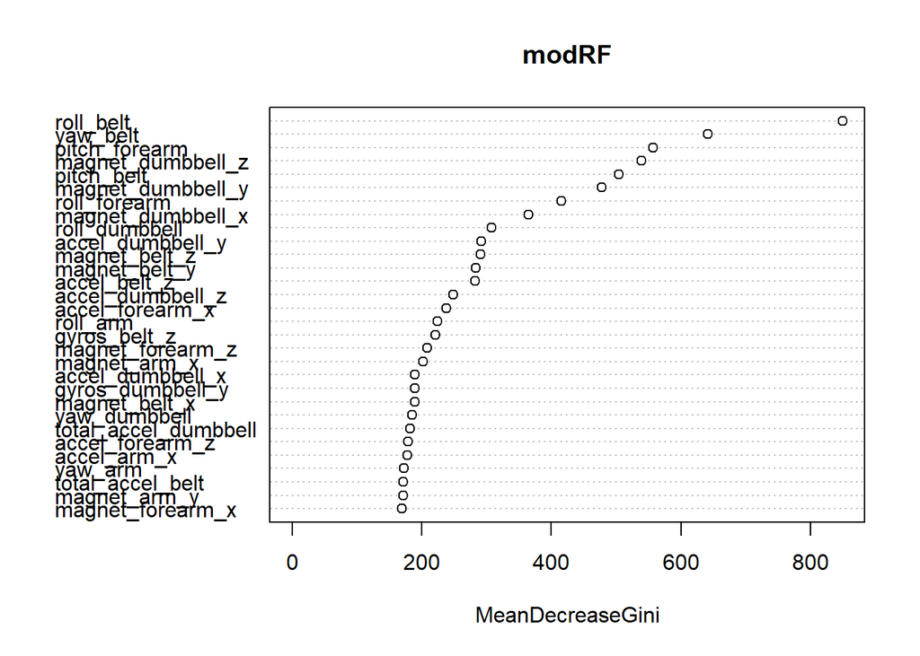

```r
#Exploring the variable importance
varImpPlot(modRF,type=2)
```

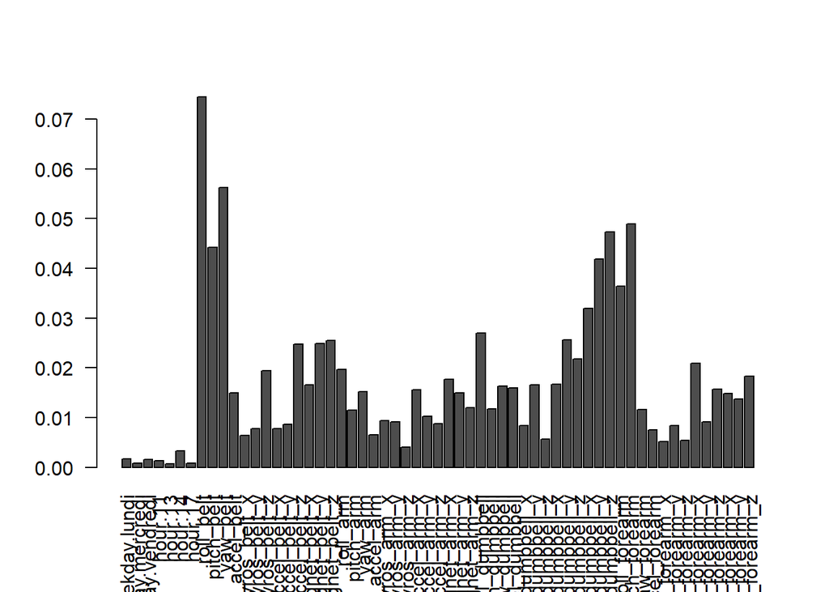

```r
barplot(t(importance(modRF)/sum(importance(modRF))), las=2)
```

```r
#trying out an lda classifier
set.seed(123)
modLDA <- train(classe ~., data = trainData, method = "lda", trControl=trainControl(method='cv', number=10), verbose = FALSE)
predicLDA <- predict(modLDA, newdata = testData)

confusionMatrix(predicLDA, testData$classe)
```

```
## Confusion Matrix and Statistics
##
##           Reference
## Prediction    A    B    C    D    E
##          A 1145  123   84   49   23
##          B   34  595   70   27  100
##          C   91  127  560   86   66
##          D   96   37  108  609   74
##          E    1   47   16   15  619
##
## Overall Statistics
##
##                Accuracy : 0.7347
##                  95% CI : (0.722, 0.7471)
##     No Information Rate : 0.2847
##     P-Value [Acc > NIR] : < 2.2e-16
##
##                   Kappa : 0.6643
##  Mcnemar's Test P-Value : < 2.2e-16
##
## Statistics by Class:
##
##                      Class: A Class: B Class: C Class: D Class: E
## Sensitivity            0.8376   0.6405   0.6683   0.7748   0.7018
## Specificity            0.9188   0.9404   0.9067   0.9216   0.9798
## Pos Pred Value         0.8041   0.7203   0.6022   0.6591   0.8868
## Neg Pred Value         0.9343   0.9160   0.9282   0.9544   0.9359
## Prevalence             0.2847   0.1935   0.1745   0.1637   0.1837
## Detection Rate         0.2384   0.1239   0.1166   0.1268   0.1289
## Detection Prevalence   0.2965   0.1720   0.1937   0.1924   0.1454
## Balanced Accuracy      0.8782   0.7904   0.7875   0.8482   0.8408
```

73% accuracy is better than the rpart classifier, but still nowhere near as good as the random forest.

## Final Model

```r
set.seed(123)

#Getting the useless columns out of the training testing and validation sets
newTrain <- trainData %>% dplyr::select(-c(1:7))
newTest <- testData %>% dplyr::select(-c(1:7))
ft <- finalTest %>% dplyr::select(-c(1:7))

#Retraining the model
modRF2 <- randomForest(classe ~., data = newTrain)


#Testing the out of sample error on the "testing set" used as validation
predicTreeV2 <- predict(modRF2, newdata = ft)

confusionMatrix(predicTreeV2, ft$classe)
```

```
## Confusion Matrix and Statistics
##
##           Reference
## Prediction    A    B    C    D    E
##          A 5471    1    0    0    0
##          B    0 3717    1    0    0
##          C    0    0 3349   13    0
##          D    0    0    2 3134    2
##          E    0    0    0    0 3526
##
## Overall Statistics
##
##                Accuracy : 0.999
##                  95% CI : (0.9985, 0.9994)
##     No Information Rate : 0.2847
##     P-Value [Acc > NIR] : < 2.2e-16
##
##                   Kappa : 0.9987
##  Mcnemar's Test P-Value : NA
##
## Statistics by Class:
##
##                      Class: A Class: B Class: C Class: D Class: E
## Sensitivity            1.0000   0.9997   0.9991   0.9959   0.9994
## Specificity            0.9999   0.9999   0.9992   0.9998   1.0000
## Pos Pred Value         0.9998   0.9997   0.9961   0.9987   1.0000
## Neg Pred Value         1.0000   0.9999   0.9998   0.9992   0.9999
## Prevalence             0.2847   0.1935   0.1744   0.1638   0.1836
## Detection Rate         0.2847   0.1934   0.1743   0.1631   0.1835
## Detection Prevalence   0.2848   0.1935   0.1750   0.1633   0.1835
## Balanced Accuracy      1.0000   0.9998   0.9991   0.9978   0.9997
```